# Cyclistic Data Analyst Project

## Transformacion de Datos

### Comprobación de datos nulos

```python
cyclistic_df.isna().sum()
```

```
ride_id                    0
rideable_type              0
started_at                 0
ended_at                   0
start_station_name    600479
start_station_id      600586
end_station_name      646471
end_station_id        646548
start_lat                  0
start_lng                  0
end_lat                 4831
end_lng                 4831
member_casual              0
dtype: int64
```

### Eliminacion de datos nulos

```python
cyclistic_df = cyclistic_df.dropna()
```

```python
# Comprobacion de eliminacion de datos nulos
cyclistic_df.isna().sum()
```

```
ride_id               0
rideable_type         0
started_at            0
ended_at              0
start_station_name    0
start_station_id      0
end_station_name      0
end_station_id        0
start_lat             0
start_lng             0
end_lat               0
end_lng               0
member_casual         0
dtype: int64
```

```python
# review del nuevo dataframe
cyclistic_df
```

|  | ride_id | rideable_type | started_at | ended_at | start_station_name | start_station_id | end_station_name | end_station_id | start_lat | start_lng | end_lat | end_lng | member_casual |
| --- | --- | --- | --- | --- | --- | --- | --- | --- | --- | --- | --- | --- | --- |
| 0 | BD0A6FF6FFF9B921 | electric_bike | 2020-11-01 13:36:00 | 2020-11-01 13:45:40 | Dearborn St & Erie St | 110 | St. Clair St & Erie St | 211 | 41.894177 | -87.629127 | 41.894434 | -87.623379 | casual |
| 1 | 96A7A7A4BDE4F82D | electric_bike | 2020-11-01 10:03:26 | 2020-11-01 10:14:45 | Franklin St & Illinois St | 672 | Noble St & Milwaukee Ave | 29 | 41.890959 | -87.635343 | 41.900675 | -87.662480 | casual |
| 2 | C61526D06582BDC5 | electric_bike | 2020-11-01 00:34:05 | 2020-11-01 01:03:06 | Lake Shore Dr & Monroe St | 76 | Federal St & Polk St | 41 | 41.880983 | -87.616754 | 41.872054 | -87.629550 | casual |
| 3 | E533E89C32080B9E | electric_bike | 2020-11-01 00:45:16 | 2020-11-01 00:54:31 | Leavitt St & Chicago Ave | 659 | Stave St & Armitage Ave | 185 | 41.895499 | -87.682013 | 41.917744 | -87.691392 | casual |
| 4 | 1C9F4EF18C168C60 | electric_bike | 2020-11-01 15:43:25 | 2020-11-01 16:16:52 | Buckingham Fountain | 2 | Buckingham Fountain | 2 | 41.876497 | -87.620358 | 41.876448 | -87.620338 | casual |
| ... | ... | ... | ... | ... | ... | ... | ... | ... | ... | ... | ... | ... | ... |
| 5378829 | BA077FDD42DABF12 | classic_bike | 2021-10-14 21:45:05 | 2021-10-14 22:07:25 | Franklin St & Chicago Ave | 13017 | Michigan Ave & 14th St | TA1307000124 | 41.896747 | -87.635668 | 41.864059 | -87.623727 | casual |
| 5378830 | B7D99254E798AA6B | classic_bike | 2021-10-02 15:28:28 | 2021-10-02 15:51:02 | Streeter Dr & Grand Ave | 13022 | Michigan Ave & 14th St | TA1307000124 | 41.892278 | -87.612043 | 41.864059 | -87.623727 | casual |
| 5378831 | BCCFD66DA466400F | electric_bike | 2021-10-08 16:47:10 | 2021-10-08 16:52:43 | Calumet Ave & 21st St | 15546 | Michigan Ave & 14th St | TA1307000124 | 41.854055 | -87.619187 | 41.864009 | -87.623601 | member |
| 5378832 | 623E0F6F50CDD6E4 | classic_bike | 2021-10-08 07:49:47 | 2021-10-08 07:55:15 | Calumet Ave & 21st St | 15546 | Michigan Ave & 14th St | TA1307000124 | 41.854184 | -87.619154 | 41.864059 | -87.623727 | member |
| 5378833 | 83FA6AC52B7B7A7B | classic_bike | 2021-10-02 12:55:45 | 2021-10-02 13:21:10 | Winthrop Ave & Lawrence Ave | TA1308000021 | Sheffield Ave & Fullerton Ave | TA1306000016 | 41.968812 | -87.657659 | 41.925602 | -87.653708 | member |

4492727 rows × 13 columns

```python
# Cambio de nombre columna member_casual a user_types
cyclistic_df = cyclistic_df.rename(columns={'member_casual': 'user_types'})
```

### Comprobacion de tipos de datos

```python
cyclistic_df.dtypes
```

```
ride_id                object
rideable_type          object
started_at             object
ended_at               object
start_station_name     object
start_station_id       object
end_station_name       object
end_station_id         object
start_lat             float64
start_lng             float64
end_lat               float64
end_lng               float64
user_types             object
dtype: object
```

```python
# Transformacion de dataos a datetime
cyclistic_df.started_at = pd.to_datetime(cyclistic_df.started_at)
cyclistic_df.ended_at = pd.to_datetime(cyclistic_df.ended_at)
```

```python
# Creacion de nuevas columnas hour - ride_minutes, ride_distance
cyclistic_df['hour'] = cyclistic_df.started_at.dt.hour

cyclistic_df['ride_minutes'] = (cyclistic_df['ended_at'] - cyclistic_df['started_at'])
cyclistic_df['ride_minutes'] = pd.to_numeric(cyclistic_df['ride_minutes'])
cyclistic_df['ride_minutes'] = np.round(cyclistic_df['ride_minutes']/6e+10, 2)
```

```python
# Calculo de la distancia de viaje usando la formula
# de Haversine, la cual se usa para calcular la distancia
# entre dos punto geograficos
import math
def haversine(lat1, lon1, lat2, lon2):
  """
    Esta funcion calcula la distancia entre dos puntos
    geograficos, utilizando la formula de Haversine
  """
  rad=math.pi/180
  distance_lat=lat2-lat1
  distance_lon=lon2-lon1
  R=6372.795477598  #radio terrestre
  a=(math.sin(rad*distance_lat/2))**2 + math.cos(rad*lat1)*math.cos(rad*lat2)*(math.sin(rad*distance_lon/2))**2
  distancia=2*R*math.asin(math.sqrt(a))
  return round(distancia, 2)
```

```python
cyclistic_df['ride_distance'] = cyclistic_df.apply(lambda d: haversine(d.start_lat, d.start_lng, d.end_lat, d.end_lng), axis=1 )
```

```python
cyclistic_df['month'] = cyclistic_df.started_at.dt.month_name()

cyclistic_df['ride_day'] = cyclistic_df.started_at.dt.day_name()
```

```python
# stadisticas de la duracion de viaje en minutos
cyclistic_df.ride_minutes.describe()
```

```
count    4.492727e+06
mean     2.029369e+01
std      3.038178e+02
min     -2.904997e+04
25%      7.120000e+00
50%      1.252000e+01
75%      2.267000e+01
max      5.594415e+04
Name: ride_minutes, dtype: float64
```

Como se puede ver al momento de analizar el dato menor en cuanto a los minutos de viaje tenemos un numero negativo, lo cual nos indicca que la fecha de inicio de la carrera es mayor a la de fin, esto se puede dar por un error al momento de tomar los datos, o algun error referente a la conexion a red de las bicicletas y la empresa.

DEbido a esto para el analisis he decidido eliminar todos los datos cuya fecha de inicio sea mayor a la de fin

```python
# filtracion de datos, minutos mayor a 0
df = cyclistic_df[ cyclistic_df.ride_minutes > 0 ]
```

```python
# comprobacion estadisticas de minutos de viaje
df.ride_minutes.describe()
```

```
count    4.491323e+06
mean     2.230601e+01
std      1.867824e+02
min      2.000000e-02
25%      7.120000e+00
50%      1.252000e+01
75%      2.267000e+01
max      5.594415e+04
Name: ride_minutes, dtype: float64
```

```python
df.head(4)
```

|  | ride_id | rideable_type | started_at | ended_at | start_station_name | start_station_id | end_station_name | end_station_id | start_lat | start_lng | end_lat | end_lng | user_types | hour | ride_minutes | ride_distance | month | ride_day |
| --- | --- | --- | --- | --- | --- | --- | --- | --- | --- | --- | --- | --- | --- | --- | --- | --- | --- | --- |
| 0 | BD0A6FF6FFF9B921 | electric_bike | 2020-11-01 13:36:00 | 2020-11-01 13:45:40 | Dearborn St & Erie St | 110 | St. Clair St & Erie St | 211 | 41.894177 | -87.629127 | 41.894434 | -87.623379 | casual | 13 | 9.67 | 0.48 | November | Sunday |
| 1 | 96A7A7A4BDE4F82D | electric_bike | 2020-11-01 10:03:26 | 2020-11-01 10:14:45 | Franklin St & Illinois St | 672 | Noble St & Milwaukee Ave | 29 | 41.890959 | -87.635343 | 41.900675 | -87.662480 | casual | 10 | 11.32 | 2.49 | November | Sunday |
| 2 | C61526D06582BDC5 | electric_bike | 2020-11-01 00:34:05 | 2020-11-01 01:03:06 | Lake Shore Dr & Monroe St | 76 | Federal St & Polk St | 41 | 41.880983 | -87.616754 | 41.872054 | -87.629550 | casual | 0 | 29.02 | 1.45 | November | Sunday |
| 3 | E533E89C32080B9E | electric_bike | 2020-11-01 00:45:16 | 2020-11-01 00:54:31 | Leavitt St & Chicago Ave | 659 | Stave St & Armitage Ave | 185 | 41.895499 | -87.682013 | 41.917744 | -87.691392 | casual | 0 | 9.25 | 2.59 | November | Sunday |

### Analisis

#### Tipos de Bicicletas

```python
bike_types = df.rideable_type.unique()
for bike in bike_types:
  print(bike.title())
```

```
Electric_Bike
Docked_Bike
Classic_Bike
```

#### Tipos de miembros

```python
member_types = df.user_types.unique()
for member in member_types:
  print(member.title())
```

```
Casual
Member
```

#### Estaciones y numero de estaciones de incio

```python
for station in df.start_station_name.unique():
  print(station)

print(f'Numero de estaciones: {cyclistic_df.start_station_name.nunique()}')
```

```
Dearborn St & Erie St
Franklin St & Illinois St
Lake Shore Dr & Monroe St
Leavitt St & Chicago Ave
Buckingham Fountain
Wabash Ave & 16th St
Marshfield Ave & Cortland St
Clark St & 9th St (AMLI)
Michigan Ave & 8th St
Lakeview Ave & Fullerton Pkwy
Mies van der Rohe Way & Chicago Ave
Western Ave & 21st St
Damen Ave & Cullerton St
Wells St & Polk St
Paulina Ave & North Ave
Montrose Harbor
Theater on the Lake
Ashland Ave & Grace St
Dusable Harbor
Greenwood Ave & 47th St
Sheffield Ave & Wellington Ave
Southport Ave & Waveland Ave
Clark St & Montrose Ave
Damen Ave & Pierce Ave
Morgan St & Lake St
Lakefront Trail & Bryn Mawr Ave
Larrabee St & Webster Ave
Wells St & Elm St
Wilton Ave & Diversey Pkwy
Lincoln Ave & Fullerton Ave
Noble St & Milwaukee Ave
Delano Ct & Roosevelt Rd
Damen Ave & Thomas St (Augusta Blvd)
Lake Park Ave & 53rd St
Western Ave & Walton St
Michigan Ave & 14th St
Stave St & Armitage Ave
Clark St & Randolph St
Halsted St & Wrightwood Ave
Wood St & Milwaukee Ave
```

[output cut: 753 more lines]

```
Komensky Ave & 55th St
Kedzie Ave & 57th St
Central Park & Augusta Blvd
Lawler Ave & 50th St
Central Park Ave & Ohio St
Albany Ave & Belmont Ave
Milwaukee Ave & Fullerton Ave
Spaulding Ave & 63rd St
Artesian Ave & 55th St
Pulaski & Ann Lurie Pl
Indiana Ave & 133rd St
Lincoln Ave & Balmoral Ave
Kenneth Ave & 50th St
S Wentworth Ave & W 111th St
Numero de estaciones: 807
```

```python
for station in df.end_station_name.unique():
  print(station)

print(f'Numero de estaciones: {cyclistic_df.end_station_name.nunique()}')
```

```
St. Clair St & Erie St
Noble St & Milwaukee Ave
Federal St & Polk St
Stave St & Armitage Ave
Buckingham Fountain
Lake Shore Dr & Monroe St
Wabash Ave & 16th St
Larrabee St & Armitage Ave
Michigan Ave & 18th St
Lakeview Ave & Fullerton Pkwy
Clark St & Schiller St
Damen Ave & Cullerton St
Wood St & Hubbard St
Southport Ave & Clybourn Ave
Clark St & Armitage Ave
Sedgwick St & Webster Ave
Montrose Harbor
Ashland Ave & Grace St
Cannon Dr & Fullerton Ave
Greenwood Ave & 47th St
Southport Ave & Belmont Ave
Clark St & Montrose Ave
Lake Shore Dr & Wellington Ave
Sheffield Ave & Wellington Ave
Bernard St & Elston Ave
Franklin St & Lake St
Lakefront Trail & Bryn Mawr Ave
Clark St & Elm St
Larrabee St & Webster Ave
Wells St & Huron St
Damen Ave & Wellington Ave
Canal St & Harrison St
Shore Dr & 55th St
Fort Dearborn Dr & 31st St
Western Ave & Walton St
Clark St & Randolph St
Southport Ave & Waveland Ave
Sheffield Ave & Webster Ave
Lake Shore Dr & Diversey Pkwy
Stockton Dr & Wrightwood Ave
```

[output cut: 750 more lines]

```
Pulaski Rd & 51st St
Spaulding Ave & 63rd St
Pulaski & Ann Lurie Pl
Kedzie Ave & 57th St
Western Ave & 62nd St
Rockwell St & Archer Ave
Indiana Ave & 133rd St
Western Ave & Gunnison St
Sacramento Ave & Pershing Rd
N Damen Ave & W Chicago Ave
Kenneth Ave & 50th St
Artesian Ave & 55th St
S Wentworth Ave & W 111th St
Whipple St & Irving Park Rd
Numero de estaciones: 804
```

```python
# Comprobacion de diferencia entre estaciones de inicio y estaciones de fin
df.start_station_name == df.end_station_name
```

```
0          False
1          False
2          False
3          False
4           True
           ...
5378829    False
5378830    False
5378831    False
5378832    False
5378833    False
Length: 4491323, dtype: bool
```

#### Numero de Miembros

```python
df.user_types.value_counts()
```

```
member    2460716
casual    2030607
Name: user_types, dtype: int64
```

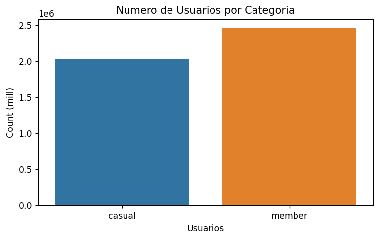

```python
plt.figure(figsize=(7, 4), dpi=125)
sns.countplot(data=df, x='user_types')
plt.xlabel('Usuarios')
plt.ylabel('Count (mill)')
plt.title('Numero de Usuarios por Categoria')
```

**Total de viajes por hora**

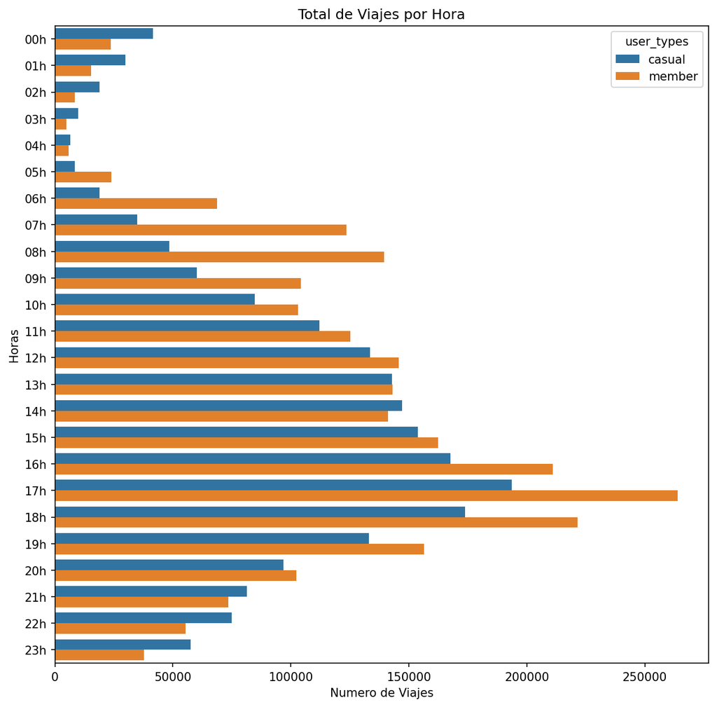

```python
plt.figure( figsize=(10, 10), dpi=150 )
sns.countplot( data= df, y= 'hour', hue= 'user_types' )
plt.yticks([0, 1, 2, 3, 4, 5, 6, 7, 8, 9, 10, 11, 12, 13, 14, 15,
            16, 17, 18, 19, 20, 21, 22, 23],
           ['00h', '01h', '02h', '03h', '04h', '05h', '06h', '07h', '08h', '09h',
            '10h', '11h', '12h', '13h', '14h', '15h', '16h', '17h', '18h', '19h',
            '20h', '21h', '22h', '23h'])
plt.ylabel('Horas')
plt.xlabel('Numero de Viajes')
plt.title('Total de Viajes por Hora')
```

Como podemos ver en la grafica los miembros anuales realizan mas viajes que los usuarios casuales, pero tambien podemos ver que los miembros casuales superan a los usuarios anuales en horas de la noche y madrugada.

Tenemos que las horas pico en cuanto a los usuarios casuales se encuentra de 11h hasta las 20h

**Viajes Totales por Dia**

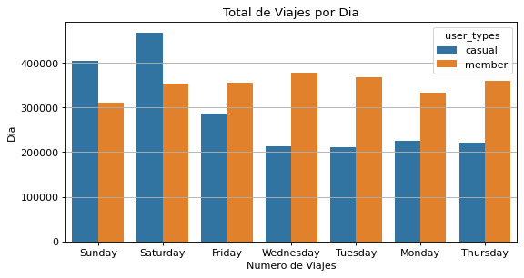

```python
plt.figure( figsize=(8, 4), dpi=80 )
sns.countplot( data= df, x= 'ride_day', hue= 'user_types' )
plt.ylabel('Dia')
plt.xlabel('Numero de Viajes')
plt.title('Total de Viajes por Dia')
```

En esta grafica se puede observar que entre semana la preferencia por viajar esta ligada a los miembros anuales, mientras que en los fines de semana hay una clara predominancia del uso de las bicicletas por parte de los miembros casuales

**Total de viajes por mes**

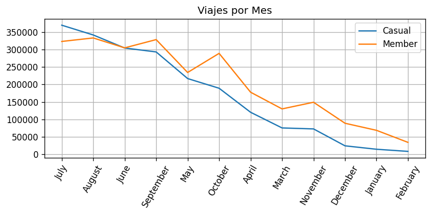

```python
plt.figure(figsize=(8, 3), dpi= 120)
sns.set_style({'axes.grid': True})
sns.lineplot(df[df['user_types'] == 'casual']['month'].value_counts().index,
             df[df['user_types'] == 'casual']['month'].value_counts().values)
sns.lineplot(df[df['user_types'] == 'member']['month'].value_counts().index,
             df[df['user_types'] == 'member']['month'].value_counts().values)
plt.legend(['Casual', 'Member'])
plt.xticks(rotation=60)
plt.title('Viajes por Mes')
```

Los picos de usos de las bicicletas por parte de los miembros casuales se dan en los memeses de Junio, Julio Agosto y Septiembre superando en cantidad el numero de viajes a los miembros anuales en los meses de Julio y Agosto.

**Distancia recorrida**

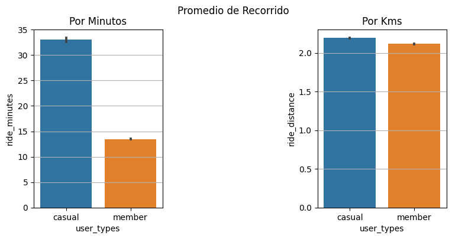

```python
fig, axs = plt.subplots(1, 2)
fig.set_size_inches(9, 4)
fig.set_dpi(100)
fig.subplots_adjust(hspace=1.2, wspace=1.2)
sns.barplot( ax=axs[0], data= df, x= df.user_types, y= df.ride_minutes)
sns.barplot(ax=axs[1],data= df, x= df.user_types, y= df.ride_distance)

axs[0].set_title('Por Minutos')
axs[1].set_title('Por Kms')
fig.suptitle('Promedio de Recorrido')
```

```python
df.nlargest(5, 'ride_minutes')[['ride_minutes', 'ride_distance']]
```

|  | ride_minutes | ride_distance |
| --- | --- | --- |
| 2230787 | 55944.15 | 4.23 |
| 2180580 | 55691.68 | 5.69 |
| 1149792 | 53921.60 | 0.69 |
| 1716817 | 52701.38 | 4.14 |
| 3005045 | 49107.15 | 4.95 |

Se puede observar claramente que los usuarios casuales hacen un uso mas extenso de las bicicletas, si vemos el promedio en minutos, los usuarios casuales superan notablemente a los miembros anuales, pero el promedio en kilometros recorridos es muy parejo, esto se puede deber a que los usuarios casuales en sus recorridos de un punto A a un punto B pueden hacer varias paradas

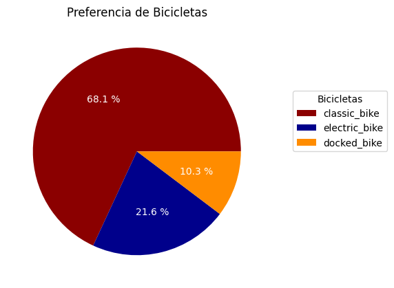

```python
plt.figure(figsize=(10, 5), dpi=100)
colores = ['darkred', 'darkblue', 'darkorange']
plt.pie(df.rideable_type.value_counts(),
        labels= df.rideable_type.value_counts().index,
        autopct='%0.1f %%', colors= colores, textprops={'color':'white'})
plt.legend(loc=(1.1, 0.5), title='Bicicletas')
plt.title('Preferencia de Bicicletas')
plt.show()
```

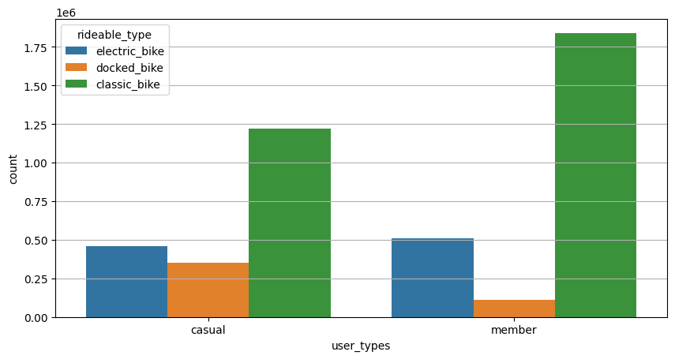

```python
plt.figure(figsize=(10, 5), dpi=100)
sns.countplot(data= df, x= df.user_types, hue=df.rideable_type)
```

Claramente las bicicletas clasicas son las preferidas de ambos tipos de usuarios

### Resumen

En este analisis se ha tratado de observar el comportamiento de los usuarios dentro de la empresa Cyclisitic, empresa dedicada al servicio de alquiler de bicicletas.

La idea del analisis era ver en que se diferencia el uso de las bicicletas por parte de usuarios casuales y usuarios miembros o con membresia anual, si bien la cantidad de usuarios con membresia anual es mayor al numero de usuarios casuales, la empresa desea incrementa el numero de miembros anuales para asi subir sus ganancias.

Observando las graficas hay ciertos patrones de ambos tipos de usuarios.

Se ha realizado un analisis exploratorio con ayuda de graficos para poder sacar conclusiones concretas y asi dar recomendaciones a los stakeholders.

### Conclusiones

- Los miembros de uso casual tienden a utilizaqr el servicio de bicicletas en altas horas de la noche y se aumente los fines de semanay en meses de verano, es decir meses de vacaciones, por lo cual se puede concluir que son personas que usan las bicicletas para hacer turismo en la ciudad
- Los usuarios con membresia anual usan mas las bicicletas entre semana y en horas pico como son de 4pm a 6pm por lo cual se puede concluir que son personas que usan este servicio para ir a su trabajo o lugar de estudios.
- El recorrido de las biciletas es mayor por parte de los usuarios casuales, claro esta que en cuanto al promedio de minutos que se usa las biciletas, el promedio de los usuarios casuales es ampliamente mayor al de los usuarios con membresia anual, pero si vemos la grafica de los kilometros recorridos la diferencia es menor, esto se puede dar porque tal vez los usuarios casuales durante su recorrido pueden hacer varias paradas para visitar diferentes lugares como museos, centros comerciales, tiendas, etc.

### Recomendaciones

Si la empresa desea incrementar sus ventas creo que deben pensar en crear nuevos planes de membresias, como membresias para familias, o precios especiales los fines de semana o tambien membresias por tiempos cortos, incluso crear planes para estudiantes.

También creo que seria bueno que la empresa realice varias encuestas para saber que tipo de personas usa su servicio es decir a que se dedica, si esta en la ciudad por negocios, por diversion, etc. Esto permitiria crecer el abanico de tipos de membresias

Se deberia crear vinculos con lugares turisticos como museos, centros culturales, centros deportivos, etc para asi mejorar el servicio, las campañas publicitarias e incluso personalizar las bicicletas para asi ganar miembros con mas frecuencia.